# 第一次作业

```python
import platform
import datetime
import sys
import os


your_name, your_code, work_counter = "杜培博", 200507340136, 1
print(f'我是：{your_name}，学号：{your_code}，这是我的第 {work_counter} 次作业。')
print('现在是', datetime.datetime.now())
print('我的机器信息如下：')
print(platform.uname())

print('\n当前工作目录：')
print(os.getcwd())
print('\n当前目录的文件信息如下：')
print(os.listdir())
print('\n我安装包的情况:')
!pip list
```

[output not shown]

[output cut: 107 more lines]

[output not shown]

## 机器学习考试成绩分析

```python
# 导入包
import matplotlib.pyplot as plt
import pandas as pd

pd.set_option('display.max_columns', None)
pd.set_option('display.width', 200)

# 设置字体
plt.rcParams['font.sans-serif'] = ['SimHei']
plt.rcParams['axes.unicode_minus'] = False
```

```python
# 读入数据
scores = pd.read_excel('E:\\File\\大二\\深度学习\\week01\\分数分析_脱敏.xlsx')

scores['及格'] = (scores['综合'] >= 60).map(int)  # 选取大于60并转化类型

# 筛选
xiaoqi = scores[scores['班级'] == '校企']
putong = scores[scores['班级'] == '普本']
```

# 成绩分布

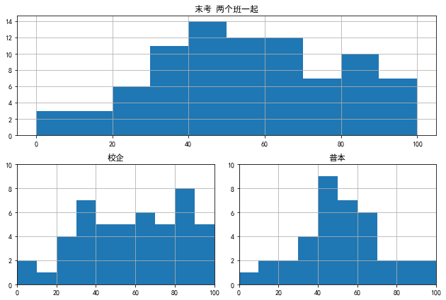

```python
bins = [0, 10, 20, 30, 40, 50, 60, 70, 80, 90, 100]
# 成绩分布图 末考
fig = plt.figure(figsize=(9, 6))    # 创建画布
ax = fig.add_subplot(211)    # 子图
ax.hist(scores['末考'], bins)    # 直方图
ax.set_title(f'末考 两个班一起')    #  添加标题
ax.grid()    # 添加网格
ax = fig.add_subplot(223)     # 子图
ax.hist(xiaoqi['末考'], bins)    # 直方图
ax.set_title(f'校企')     # 添加标题
# 设置刻度
ax.set_ylim(0, 10)
ax.set_xlim(0, 100)
ax.grid()   # 添加网格
ax = fig.add_subplot(224)    # 子图
ax.hist(putong['末考'], bins)   # 直方图
ax.set_title(f'普本')
# 设置刻度
ax.set_ylim(0, 10)
ax.set_xlim(0, 100)
ax.grid()# 网格
plt.tight_layout()
plt.savefig('末考')
```

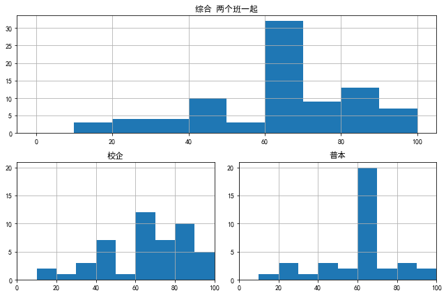

```python
# 成绩分布图 综合
fig = plt.figure(figsize=(9, 6))
ax = fig.add_subplot(211)
ax.hist(scores['综合'], bins)
ax.set_title(f'综合 两个班一起')
ax.grid()
ax = fig.add_subplot(223)
ax.hist(xiaoqi['综合'], bins)
ax.set_title(f'校企')
ax.set_ylim(0, 21)
ax.set_xlim(0, 100)
ax.set_yticks([0, 5, 10, 15, 20])
ax.grid()
ax = fig.add_subplot(224)
ax.hist(putong['综合'], bins)
ax.set_title(f'普本')
ax.set_ylim(0, 21)
ax.set_xlim(0, 100)
ax.set_yticks([0, 5, 10, 15, 20])
ax.grid()
plt.tight_layout()    # 自动调整子图尺寸
plt.savefig('综合')
```

# 分段占比

```python
# 分段统计
bins = [0, 60, 70, 80, 90, 100]
labels = ['不及格', '及格', '中等', '良好', '优秀']

# 两个班
all_level = pd.DataFrame()
all_level['末考'] = pd.cut(scores['末考'], bins, False, labels).value_counts()      # 统计counts
all_level['综合'] = pd.cut(scores['综合'], bins, False, labels).value_counts()

all_level.index.name = '分段'     # 设置index name
all_level.columns.name = '成绩'    # columns name
all_level.reset_index(inplace=True)    # 重置索引
all_level = all_level.melt(id_vars='分段', var_name='考试', value_name='成绩')    #数据转换
all_level.set_index(['分段', '考试'], inplace=True)     # 设置索引
all_level.sort_index(inplace=True)   # 索引排序
all_level['比例'] = all_level['成绩'] / scores.shape[0]   # 占比
all_level = all_level.T    # 转置

# 普本
putong_level = pd.DataFrame()
putong_level['末考'] = pd.cut(putong['末考'], bins, False, labels).value_counts()
putong_level['综合'] = pd.cut(putong['综合'], bins, False, labels).value_counts()

putong_level.index.name = '分段'      # 设置index name
putong_level.columns.name = '成绩'    # columns name
putong_level.reset_index(inplace=True)    # 重置索引
putong_level = putong_level.melt(id_vars='分段', var_name='考试', value_name='成绩')    #数据转换
putong_level.set_index(['分段', '考试'], inplace=True)    # 设置索引
putong_level.sort_index(inplace=True)   # 索引排序
putong_level['比例'] = putong_level['成绩'] / putong.shape[0]   # 占比
putong_level = putong_level.T    # 转置

# 校企
xiaoqi_level = pd.DataFrame()
xiaoqi_level['末考'] = pd.cut(xiaoqi['末考'], bins, False, labels).value_counts()
xiaoqi_level['综合'] = pd.cut(xiaoqi['综合'], bins, False, labels).value_counts()

xiaoqi_level.index.name = '分段'
xiaoqi_level.columns.name = '成绩'
xiaoqi_level.reset_index(inplace=True)
xiaoqi_level = xiaoqi_level.melt(id_vars='分段', var_name='考试', value_name='成绩')
xiaoqi_level.set_index(['分段', '考试'], inplace=True)
xiaoqi_level.sort_index(inplace=True)
xiaoqi_level['比例'] = xiaoqi_level['成绩'] / xiaoqi.shape[0]
xiaoqi_level = xiaoqi_level.T
```

```python
all_level  # 全体分段分布
```

| 分段 考试 | 不及格 末考 | 不及格 综合 | 及格 末考 | 及格 综合 | 中等 末考 | 中等 综合 | 良好 末考 | 良好 综合 | 优秀 末考 | 优秀 综合 |
| --- | --- | --- | --- | --- | --- | --- | --- | --- | --- | --- |
| 成绩 | 49.000000 | 24.000000 | 12.000000 | 32.000000 | 7.000000 | 9.000000 | 10.000000 | 13.000000 | 7.000000 | 7.000000 |
| 比例 | 0.576471 | 0.282353 | 0.141176 | 0.376471 | 0.082353 | 0.105882 | 0.117647 | 0.152941 | 0.082353 | 0.082353 |

```python
xiaoqi_level  # 校企班分段分布
```

| 分段 考试 | 不及格 末考 | 不及格 综合 | 及格 末考 | 及格 综合 | 中等 末考 | 中等 综合 | 良好 末考 | 良好 综合 | 优秀 末考 | 优秀 综合 |
| --- | --- | --- | --- | --- | --- | --- | --- | --- | --- | --- |
| 成绩 | 24.0 | 14.000000 | 6.000 | 12.00 | 5.000000 | 7.000000 | 8.000000 | 10.000000 | 5.000000 | 5.000000 |
| 比例 | 0.5 | 0.291667 | 0.125 | 0.25 | 0.104167 | 0.145833 | 0.166667 | 0.208333 | 0.104167 | 0.104167 |

```python
putong_level  # 普本班分段分布
```

| 分段 考试 | 不及格 末考 | 不及格 综合 | 及格 末考 | 及格 综合 | 中等 末考 | 中等 综合 | 良好 末考 | 良好 综合 | 优秀 末考 | 优秀 综合 |
| --- | --- | --- | --- | --- | --- | --- | --- | --- | --- | --- |
| 成绩 | 25.000000 | 10.00000 | 6.000000 | 20.000000 | 2.000000 | 2.000000 | 2.000000 | 3.000000 | 2.000000 | 2.000000 |
| 比例 | 0.675676 | 0.27027 | 0.162162 | 0.540541 | 0.054054 | 0.054054 | 0.054054 | 0.081081 | 0.054054 | 0.054054 |

# 两班对比

```python
xiaoqi[['末考', '综合']].describe()     # 数据集的描述
```

|  | 末考 | 综合 |
| --- | --- | --- |
| count | 48.000000 | 48.000000 |
| mean | 57.437500 | 64.512500 |
| std | 25.136992 | 21.033819 |
| min | 6.000000 | 10.200000 |
| 25% | 37.500000 | 48.275000 |
| 50% | 60.000000 | 64.800000 |
| 75% | 80.250000 | 81.600000 |
| max | 98.000000 | 97.700000 |

```python
putong[['末考', '综合']].describe()   # 数据集的描述
```

|  | 末考 | 综合 |
| --- | --- | --- |
| count | 37.000000 | 37.000000 |
| mean | 51.189189 | 59.645946 |
| std | 20.369964 | 18.072195 |
| min | 4.000000 | 10.000000 |
| 25% | 43.000000 | 51.200000 |
| 50% | 50.000000 | 60.600000 |
| 75% | 62.000000 | 68.600000 |
| max | 91.000000 | 92.500000 |

# 男女生情况：

```python
sex = scores[['学号', '性别', '及格']].groupby(['性别', '及格']).count()    # 数量
sex.reset_index(inplace=True)    # 重置索引
sex = sex.pivot('性别', '及格', '学号')   # 将数据变成表格
sex['rate'] = sex[0] / sex.sum(1)    # 占比
sex
```

| 及格 性别 | 0 | 1 | rate |
| --- | --- | --- | --- |
| 女 | 6 | 30 | 0.166667 |
| 男 | 18 | 31 | 0.367347 |

# 宿舍分析

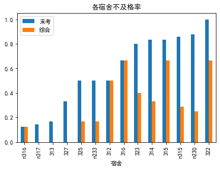

```python
room_s = scores[['学号', '宿舍', '及格']].groupby(['宿舍', '及格']).count()    # 分组聚合
room_s.reset_index(inplace=True)    # 重置索引
room_s = room_s.pivot('宿舍', '及格', '学号')    # 表格化
room_s.fillna(0, inplace=True)    # 填充缺失值
room_s['rate'] = room_s[0] / room_s.sum(1)   # 占比
room_s.sort_values('rate', inplace=True)    # 排序

scores['末考及格'] = (scores['末考'] >= 60).map(int)    # 筛选，转化为int
room_e = scores[['学号', '宿舍', '末考及格']].groupby(['宿舍', '末考及格']).count()    # 统计数量
room_e.reset_index(inplace=True)  # 重索引
room_e = room_e.pivot('宿舍', '末考及格', '学号')    # 表格化
room_e.fillna(0, inplace=True)   # 缺失值填充
room_e['rate'] = room_e[0] / room_e.sum(1)   #占比
room_e.sort_values('rate', inplace=True)   # 排序

room = pd.DataFrame()
room['末考'] = room_e['rate']
room['综合'] = room_s['rate']
room.sort_values(['末考', '综合'], inplace=True)

plt.figure(figsize=(8, 10))   # 船舰画布
room.plot.bar()    # 画图
plt.title('各宿舍不及格率')
plt.savefig('各宿舍不及格率')
```

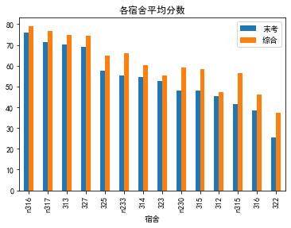

```python
# 各宿舍平均分
room_s = scores[['宿舍', '综合']].groupby('宿舍').mean()    # 分组求平均
room_e = scores[['宿舍', '末考']].groupby('宿舍').mean()
room = pd.DataFrame()
room['末考'] = room_e['末考']
room['综合'] = room_s['综合']
room.sort_values(['末考', '综合'], inplace=True, ascending=False)    # 排序

plt.figure(figsize=(8, 10))   # 创建画布
room.plot.bar()
plt.title('各宿舍平均分数')
plt.savefig('各宿舍平均分数')    # 保存图片
```

# 及格与模拟面试的相关性

```python
inter = scores[['学号', '模拟面试', '及格']].groupby(['模拟面试', '及格']).count()
inter.reset_index(inplace=True)
inter = inter.pivot('模拟面试', '及格', '学号')    # 表格化
inter['rate'] = inter[0] / inter.sum(1)   # 占比
inter
```

| 及格 模拟面试 | 0 | 1 | rate |
| --- | --- | --- | --- |
| 0 | 14 | 11 | 0.560000 |
| 1 | 10 | 50 | 0.166667 |

# 请从业务的角度，评价本次分析（我考的咋样，我学的咋样，我们宿舍的情况，我们班的情况，我有什么心得和改进的方法）

```
·我们宿舍整体情况还可以
·我们班整体情况不如校企班级
```

# 请从数据分析的角度，评价本次分析（分析的目的是否清楚，分析的方法、过程是否合理，使用的工具是否先进，分析的结果是否正确与明确，有什么改进的意见）

本次的分析，比较合理，通过数据可视化，明确的展示了两个班级的成绩分布，普本班级较为符合正态分布，校企成绩分布比较均匀，总体普本不如校企

# 请从代码的角度，评价本次分析（逐行理解代码的意义，逐行注释代码，思考如何改进）

# ·再现并理解D2L书 2.2的所有代码

# 2.2.1 创建 TENSOR

## TENSOR：是一个多维数组，它是标量、向量、矩阵的高维拓展，是pytorch的一种数据类型

```python
# 导入torch
import torch

# 创建⼀个5x3的未初始化的 Tensor
x = torch.empty(5, 3)
print(x)
```

```
tensor([[0., 0., 0.],
        [0., 0., 0.],
        [0., 0., 0.],
        [0., 0., 0.],
        [0., 0., 0.]])
```

```python
# 创建⼀个5x3的随机初始化的 Tensor
x = torch.rand(5, 3)
print(x)
```

```
tensor([[0.2331, 0.4094, 0.7212],
        [0.7949, 0.6118, 0.0546],
        [0.6296, 0.5514, 0.7582],
        [0.3670, 0.7298, 0.7006],
        [0.1201, 0.1677, 0.0562]])
```

```python
x = torch.zeros(5, 3, dtype=torch.long)
print(x)
```

```
tensor([[0, 0, 0],
        [0, 0, 0],
        [0, 0, 0],
        [0, 0, 0],
        [0, 0, 0]])
```

```python
# 直接根据数据创建
x = torch.tensor([5.5, 3])
print(x)
```

```
tensor([5.5000, 3.0000])
```

```python
# 通过现有的 Tensor 来创建
x = x.new_ones(5, 3, dtype=torch.float64) # 返回的tensor默认具有相同的torch.dtype和torch.device
print(x)
x = torch.randn_like(x, dtype=torch.float) # 指定新的数据类型
print(x)
```

```
tensor([[1., 1., 1.],
        [1., 1., 1.],
        [1., 1., 1.],
        [1., 1., 1.],
        [1., 1., 1.]], dtype=torch.float64)
tensor([[-1.9394, -1.1937,  0.6901],
        [ 1.2902,  0.7923, -0.1193],
        [ 1.0205, -0.1059, -0.1711],
        [-0.1632,  1.0456,  1.2737],
        [ 0.3771, -2.5226,  0.9937]])
```

### 查看size

```python
print(x.size())
print(x.shape)
```

```
torch.Size([5, 3])
torch.Size([5, 3])
```

# 2.2.2 操作

### 加法

加法形式⼀

```python
y = torch.rand(5, 3)
print(x + y)
```

```
tensor([[-1.7914, -0.4284,  1.1340],
        [ 1.7242,  1.5345, -0.0097],
        [ 1.3933,  0.0337,  0.1646],
        [ 0.7175,  1.7406,  2.1863],
        [ 1.0759, -1.6914,  1.1563]])
```

加法形式⼆

```python
print(torch.add(x, y))
```

```
tensor([[-1.7914, -0.4284,  1.1340],
        [ 1.7242,  1.5345, -0.0097],
        [ 1.3933,  0.0337,  0.1646],
        [ 0.7175,  1.7406,  2.1863],
        [ 1.0759, -1.6914,  1.1563]])
```

加法形式三、inplace

```python
# adds x to y
y.add_(x)
print(y)
```

```
tensor([[-1.7914, -0.4284,  1.1340],
        [ 1.7242,  1.5345, -0.0097],
        [ 1.3933,  0.0337,  0.1646],
        [ 0.7175,  1.7406,  2.1863],
        [ 1.0759, -1.6914,  1.1563]])
```

### 索引

索引出来的结果与 原数据共享内存，也即修改⼀个，另⼀个会跟着修改

```python
y = x[0, :]
y += 1
print(y)
print(x[0, :]) # 源tensor也被改了
```

```
tensor([-0.9394, -0.1937,  1.6901])
tensor([-0.9394, -0.1937,  1.6901])
```

### 改变形状

```python
y = x.view(15)
z = x.view(-1, 5) # -1所指的维度可以根据其他维度的值推出来
print(x.size(), y.size(), z.size())
```

```
torch.Size([5, 3]) torch.Size([15]) torch.Size([3, 5])
```

```python
x += 1
print(x)
print(y) # 共享数据
```

[output not shown]

item函数将⼀个标量 Tensor 转换成⼀个Python number

```python
x = torch.randn(1)
print(x)
print(x.item())
```

```
tensor([-0.7293])
-0.7292644381523132
```

# 2.2.3 ⼴播机制

当对两个形状不同的 Tensor 按元素运算 时，可能会触发⼴播（broadcasting）机制：先适当复制元素使这两个 Tensor 形状相同后再按元素 运算

```python
x = torch.arange(1, 3).view(1, 2)
print(x)
y = torch.arange(1, 4).view(3, 1)
print(y)
print(x + y)
```

```
tensor([[1, 2]])
tensor([[1],
        [2],
        [3]])
tensor([[2, 3],
        [3, 4],
        [4, 5]])
```

# 2.2.4 运算的内存开销

索引、 view 是不会开辟新内存的，⽽像 y = x + y 这样的运算是会新开内存的

```python
# 用id函数查看内存是否相同
x = torch.tensor([1, 2])
y = torch.tensor([3, 4])
id_before = id(y)
y = y + x
print(id(y) == id_before) # False
```

```
False
```

如果想指定结果到原来的 y 的内存，可以把 x + y 的结果通过 [:] 写进 y 对应的内存中

```python
x = torch.tensor([1, 2])
y = torch.tensor([3, 4])
id_before = id(y)
y[:] = y + x
print(id(y) == id_before) # True
```

```
True
```

我们还可以使⽤运算符全名函数中的 out 参数或者⾃加运算符 += (也即 add*() )达到上述效果，例如 torch.add(x, y, out=y) 和 y += x ( y.add*(x) )

```python
x = torch.tensor([1, 2])
y = torch.tensor([3, 4])
id_before = id(y)
torch.add(x, y, out=y) # y += x, y.add_(x)
print(id(y) == id_before) # True
```

```
True
```

# 2.2.5 TENSOR 和NUMPY相互转换

⽤ numpy() 和 from_numpy() 将 Tensor 和NumPy中的数组相互转换，两个函数所产⽣的的 Tensor 和NumPy中的数组共享相同的内存（所以他们之间的转换很 快），改变其中⼀个时另⼀个也会改变！！！

```python
# 使⽤ numpy() 将 Tensor 转换成NumPy数组:
a = torch.ones(5)
b = a.numpy()
print(a, b)
a += 1
print(a, b)
b += 1
print(a, b)
```

```
tensor([1., 1., 1., 1., 1.]) [1. 1. 1. 1. 1.]
tensor([2., 2., 2., 2., 2.]) [2. 2. 2. 2. 2.]
tensor([3., 3., 3., 3., 3.]) [3. 3. 3. 3. 3.]
```

```python
# NumPy数组转 Tensor，使⽤ from_numpy() 将NumPy数组转换成 Tensor
# 所有在CPU上的 Tensor （除了 CharTensor ）都⽀持与NumPy数组相互转换
import numpy as np
a = np.ones(5)
b = torch.from_numpy(a)
print(a, b)
a += 1
print(a, b)
b += 1
print(a, b)
```

```
[1. 1. 1. 1. 1.] tensor([1., 1., 1., 1., 1.], dtype=torch.float64)
[2. 2. 2. 2. 2.] tensor([2., 2., 2., 2., 2.], dtype=torch.float64)
[3. 3. 3. 3. 3.] tensor([3., 3., 3., 3., 3.], dtype=torch.float64)
```

```python
# 此外上⾯提到还有⼀个常⽤的⽅法就是直接⽤ torch.tensor() 将NumPy数组转换成 Tensor ，需要
# 注意的是该⽅法总是会进⾏数据拷⻉，返回的 Tensor 和原来的数据不再共享内存
c = torch.tensor(a)
a += 1
print(a, c)
```

```
[4. 4. 4. 4. 4.] tensor([3., 3., 3., 3., 3.], dtype=torch.float64)
```

# 2.2.6 TENSOR ON GPU

⽤⽅法 to() 可以将 Tensor 在CPU和GPU（需要硬件⽀持）之间相互移动

```python
# 以下代码只有在PyTorch GPU版本上才会执⾏
if torch.cuda.is_available():
 device = torch.device("cuda") # GPU
 y = torch.ones_like(x, device=device) # 直接创建⼀个在GPU上的Tensor
 x = x.to(device) # 等价于 .to("cuda")
 z = x + y
 print(z)
 print(z.to("cpu", torch.double)) # to()还可以同时更改数据类型
```

```
tensor([2, 3], device='cuda:0')
tensor([2., 3.], dtype=torch.float64)
```